# Northcott Medulloblastoma: Group differences in LV expression

**CCDL 2018**

In this notebook, we’ll plot the differences in PLIER latent variable expression between the three subgroups: SHH, Group 3, and Group 4.

Our objective is to learn about melting wide data, wrangling data, and using `ggplot2` along the way. Here’s a handy [ggplot2 cheatsheet to help](https://www.rstudio.com/wp-content/uploads/2015/03/ggplot2-cheatsheet.pdf).

## First, a note on tidy data

In order to use `ggplot2`, we’ll need the data in “long” or “tidy” format. `PLIER` outputs what we want to plot in what we call “wide” format.

Read more about tidy data [here](https://cran.r-project.org/web/packages/tidyr/vignettes/tidy-data.html).

To quote from Hadley Wickham’s [R for Data Science](https://r4ds.had.co.nz/):

> There are three interrelated rules which make a dataset tidy: * Each variable must have its own column. * Each observation must have its own row. * Each value must have its own cell.

Let’s look at a toy example.

```r
set.seed(12345)
toy_df <- data.frame(
  cbind(c("GENEA", "GENEB", "GENEC"),
        matrix(rnorm(30), ncol = 10))
)
colnames(toy_df) <- c("Gene", paste0("Sample", 1:10))
```

`toy_df` is now in “wide” format.

```r
toy_df
```

| Gene | Sample1 | Sample2 | Sample3 | Sample4 | Sample5 | Sample6 | Sample7 | Sample8 | Sample9 | Sample10 |
| --- | --- | --- | --- | --- | --- | --- | --- | --- | --- | --- |
| GENEA | 0.585528817843856 | -0.453497173462763 | 0.630098551068391 | -0.919322002474128 | 0.370627864257954 | 0.816899839520583 | 1.12071265166956 | 1.45578508247686 | -1.59770951669631 | 0.620379801298422 |
| GENEB | 0.709466017509524 | 0.605887455840394 | -0.276184105225216 | -0.116247806352002 | 0.520216457554957 | -0.886357521243213 | 0.298723699267293 | -0.644328429231302 | 1.80509751881082 | 0.612123492650849 |
| GENEC | -0.109303314681054 | -1.81795596770373 | -0.284159743943371 | 1.81731204370422 | -0.750531994502331 | -0.331577589942552 | 0.779621924555324 | -1.55313740522969 | -0.481647363694637 | -0.162310976918126 |

Let’s get it into “long” format.

```r
toy_long_df <- reshape2::melt(toy_df, id.vars = "Gene",
                              variable.name = "Sample",
                              value.name = "Expression")
```

```
attributes are not identical across measure variables; they will be dropped
```

```r
toy_long_df
```

| Gene | Sample | Expression |
| --- | --- | --- |
| GENEA | Sample1 | 0.585528817843856 |
| GENEB | Sample1 | 0.709466017509524 |
| GENEC | Sample1 | -0.109303314681054 |
| GENEA | Sample2 | -0.453497173462763 |
| GENEB | Sample2 | 0.605887455840394 |
| GENEC | Sample2 | -1.81795596770373 |
| GENEA | Sample3 | 0.630098551068391 |
| GENEB | Sample3 | -0.276184105225216 |
| GENEC | Sample3 | -0.284159743943371 |
| GENEA | Sample4 | -0.919322002474128 |

[output cut: 20 more lines]

Let’s remove these toy examples from the workspace.

```r
rm(toy_df, toy_long_df)
```

## Libraries and functions

```r
library(ggplot2)
library(dplyr)
library(ggsignif)
```

## Directories and files

```r
# directory for the data
data_dir <- file.path("data", "GSE37382")
results_dir <- "results"
# directory where we will save any plots
plots_dir <- "plots"
# directory where we'll put the PLIER model
model_dir <- "models"
# metadata file that has been cleaned
metadata_file <- file.path(data_dir, "GSE37382_cleaned_metadata.tsv")
# PLIER model trained in third notebook
plier_file <- file.path(model_dir, "GSE37382_PLIER_model.RDS")
```

**Output**

```r
lv_plot <- file.path(plots_dir, "LV13_boxplot.pdf")
```

## Read in data

### Sample metadata

We’ll use the sample metadata, which contains the subgroup information, in our plotting.

```r
sample_meta_df <- readr::read_tsv(metadata_file)
```

### PLIER model

```r
plier_results <- readr::read_rds(plier_file)
```

We’ll focus on the significant (`FDR < 0.05` and `AUC > 0.75`) latent variables for now. Let’s get the indices of those LVs.

```r
sig_summary_df <- plier_results$summary %>%
  dplyr::filter(FDR < 0.05,
                AUC > 0.75)
sig_index <- unique(sig_summary_df$`LV index`)
```

Let’s get the B matrix out of `plier_results` and filter it to only the significant LVs.

```r
b_matrix <- plier_results$B
sig_b_matrix <- b_matrix[as.integer(sig_index), ]
# add LV column
sig_b_wide <- tibble::rownames_to_column(as.data.frame(sig_b_matrix),
                                         var = "LV")
```

### Tidy

Let’s look at what format this is in currently.

```r
sig_b_wide[1:5, 1:5]
```

|  | LV | GSM917011 | GSM917014 | GSM917018 | GSM917016 |
| --- | --- | --- | --- | --- | --- |
| 1 | 5,REACTOME_PEPTIDE_CHAIN_ELONGATION | 0.3206897 | 0.6824313 | 0.6255710 | 0.2673414 |
| 2 | 9,MIPS_55S_RIBOSOME_MITOCHONDRIAL | 0.4982914 | 1.3799692 | 0.8995910 | 0.9651698 |
| 3 | 13,SVM T cells CD4 memory activated | -0.2683385 | -0.3407124 | -0.6652111 | -0.9906756 |
| 4 | 16,PID_FANCONI_PATHWAY | 0.8355989 | 0.8246400 | 0.7526549 | -0.4510635 |
| 5 | 17,PID_INTEGRIN1_PATHWAY | 0.3894202 | -0.3456440 | -0.1034677 | 0.5236183 |

We want this in long format. We’ll use `reshape2::melt` to do this just like in the toy example above.

```r
sig_b_df <- reshape2::melt(sig_b_wide, id.vars = "LV", variable.name = "Sample",
                           value.name = "Expression_level")
head(sig_b_df)
```

|  | LV | Sample | Expression_level |
| --- | --- | --- | --- |
| 1 | 5,REACTOME_PEPTIDE_CHAIN_ELONGATION | GSM917011 | 0.3206897 |
| 2 | 9,MIPS_55S_RIBOSOME_MITOCHONDRIAL | GSM917011 | 0.4982914 |
| 3 | 13,SVM T cells CD4 memory activated | GSM917011 | -0.2683385 |
| 4 | 16,PID_FANCONI_PATHWAY | GSM917011 | 0.8355989 |
| 5 | 17,PID_INTEGRIN1_PATHWAY | GSM917011 | 0.3894202 |
| 6 | 19,SVM Neutrophils | GSM917011 | -0.2523108 |

Let’s add the sample metadata to this `data.frame` with `inner_join`.

```r
b_df <- inner_join(x = sig_b_df, y = sample_meta_df,
                   by = c("Sample" = "source_name"))
```

```
Column `Sample`/`source_name` joining factor and character vector, coercing into character vector
```

```r
head(b_df)
```

|  | LV | Sample | Expression_level | sample_identifier | tissue_type | age | histology | sex | subgroup |
| --- | --- | --- | --- | --- | --- | --- | --- | --- | --- |
| 1 | 5,REACTOME_PEPTIDE_CHAIN_ELONGATION | GSM917011 | 0.3206897 | MB-7 | Primary medulloblastoma | 7.2 | Classic | M | SHH |
| 2 | 9,MIPS_55S_RIBOSOME_MITOCHONDRIAL | GSM917011 | 0.4982914 | MB-7 | Primary medulloblastoma | 7.2 | Classic | M | SHH |
| 3 | 13,SVM T cells CD4 memory activated | GSM917011 | -0.2683385 | MB-7 | Primary medulloblastoma | 7.2 | Classic | M | SHH |
| 4 | 16,PID_FANCONI_PATHWAY | GSM917011 | 0.8355989 | MB-7 | Primary medulloblastoma | 7.2 | Classic | M | SHH |
| 5 | 17,PID_INTEGRIN1_PATHWAY | GSM917011 | 0.3894202 | MB-7 | Primary medulloblastoma | 7.2 | Classic | M | SHH |
| 6 | 19,SVM Neutrophils | GSM917011 | -0.2523108 | MB-7 | Primary medulloblastoma | 7.2 | Classic | M | SHH |

## Plotting

For illustrative purposes, we’ll pick an LV and go through using `ggplot2` to make a plot.

```r
lv <- "13,SVM T cells CD4 memory activated"
```

```r
lv13_df <- b_df %>%
  dplyr::filter(LV == lv)
```

#### Boxplot

Let’s make a boxplot, using the subgroups as groups. We’ll use defaults and then tweak different things one by one, so you can see how different functions and arguments work.

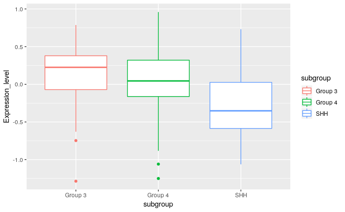

```r
lv13_df %>%
  ggplot(aes(x = subgroup, y = Expression_level,
             group = subgroup, colour = subgroup)) +
  geom_boxplot()
```

Let’s add individual points with `geom_jitter`.

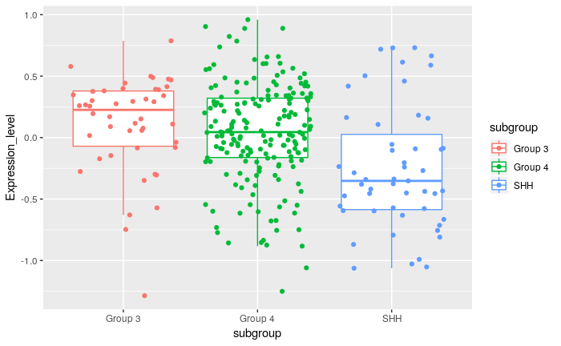

```r
lv13_df %>%
  ggplot(aes(x = subgroup, y = Expression_level,
             group = subgroup, colour = subgroup)) +
  geom_boxplot(outlier.shape = NA) +  # we remove outlier points because they
  # will be included in the jitter
  geom_jitter()
```

Let’s make the points more transparent by setting `alpha` and narrow the width of the jitter with `width`

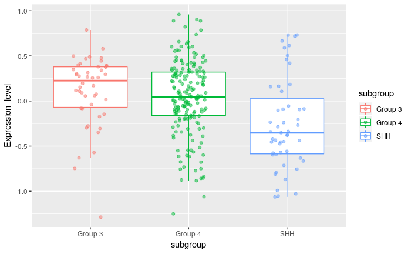

```r
lv13_df %>%
  ggplot(aes(x = subgroup, y = Expression_level,
             group = subgroup, colour = subgroup)) +
  geom_boxplot(outlier.shape = NA) +  # we remove outlier points because they
  # will be included in the jitter
  geom_jitter(width = 0.175, alpha = 0.5)
```

Let’s change the theme to something more suitable for publication.

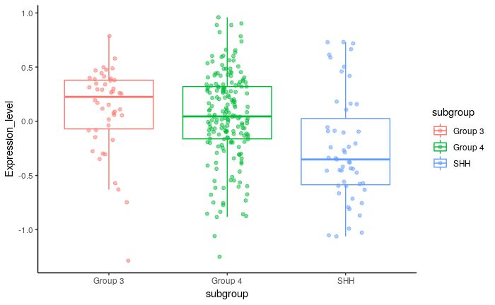

```r
lv13_df %>%
  ggplot(aes(x = subgroup, y = Expression_level,
             group = subgroup, colour = subgroup)) +
  geom_boxplot(outlier.shape = NA) +  # we remove outlier points because they
  # will be included in the jitter
  geom_jitter(width = 0.175, alpha = 0.5) +
  # add built in theme
  theme_classic()
```

Let’s add labels and a title with the `labs` function.

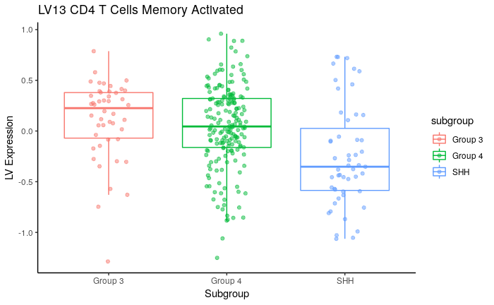

```r
lv13_df %>%
  ggplot(aes(x = subgroup, y = Expression_level,
             group = subgroup, colour = subgroup)) +
  geom_boxplot(outlier.shape = NA) +  # we remove outlier points because they
  # will be included in the jitter
  geom_jitter(width = 0.175, alpha = 0.5) +
  # add built in theme
  theme_classic() +
  labs(x = "Subgroup", y = "LV Expression", title = "LV13 CD4 T Cells Memory Activated")
```

Let’s center the title and make it bold with `theme` and `element_text`.

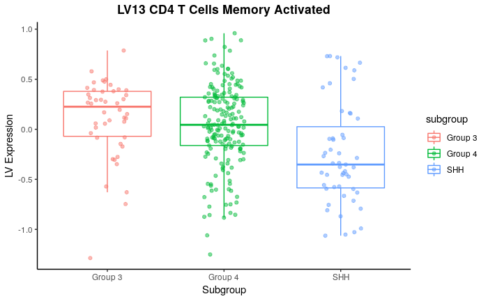

```r
lv13_df %>%
  ggplot(aes(x = subgroup, y = Expression_level,
             group = subgroup, colour = subgroup)) +
  geom_boxplot(outlier.shape = NA) +  # we remove outlier points because they
  # will be included in the jitter
  geom_jitter(width = 0.175, alpha = 0.5) +
  # add built in theme
  theme_classic() +
  labs(x = "Subgroup", y = "LV Expression", title = "LV13 CD4 T Cells Memory Activated") +
  theme(plot.title = element_text(hjust = 0.5, face = "bold"))
```

Let’s put the x-axis labels on a 45 degree angle with `theme`.

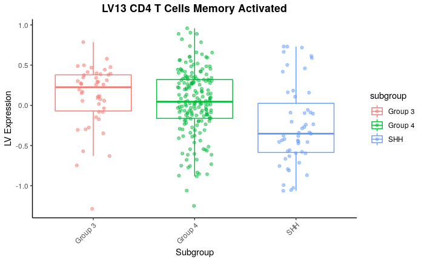

```r
lv13_df %>%
  ggplot(aes(x = subgroup, y = Expression_level,
             group = subgroup, colour = subgroup)) +
  geom_boxplot(outlier.shape = NA) +  # we remove outlier points because they
  # will be included in the jitter
  geom_jitter(width = 0.175, alpha = 0.5) +
  # add built in theme
  theme_classic() +
  labs(x = "Subgroup", y = "LV Expression", title = "LV13 CD4 T Cells Memory Activated") +
  theme(plot.title = element_text(hjust = 0.5, face = "bold"),
        axis.text.x = element_text(hjust = 1, angle = 45))
```

Let’s get rid of the legend since it’s redundant.

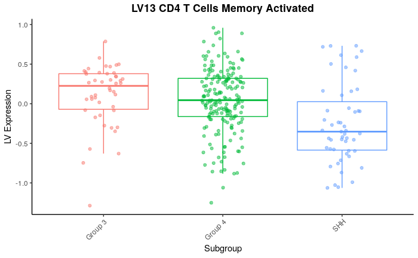

```r
lv13_df %>%
  ggplot(aes(x = subgroup, y = Expression_level,
             group = subgroup, colour = subgroup)) +
  geom_boxplot(outlier.shape = NA) +  # we remove outlier points because they
  # will be included in the jitter
  geom_jitter(width = 0.175, alpha = 0.5) +
  # add built in theme
  theme_classic() +
  labs(x = "Subgroup", y = "LV Expression", title = "LV13 CD4 T Cells Memory Activated") +
  theme(plot.title = element_text(hjust = 0.5, face = "bold"),
        axis.text.x = element_text(hjust = 1, angle = 45),
        legend.position = "none")
```

Let’s use colors that are consistent with our clustering notebook with `scale_color_manual`.

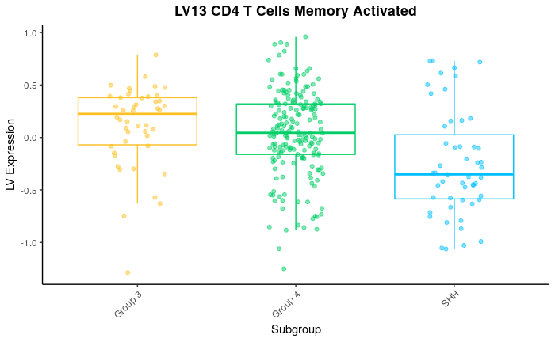

```r
lv13_df %>%
  ggplot(aes(x = subgroup, y = Expression_level,
             group = subgroup, colour = subgroup)) +
  geom_boxplot(outlier.shape = NA) +  # we remove outlier points because they
  # will be included in the jitter
  geom_jitter(width = 0.175, alpha = 0.5) +
  # add built in theme
  theme_classic() +
  labs(x = "Subgroup", y = "LV Expression", title = "LV13 CD4 T Cells Memory Activated") +
  theme(plot.title = element_text(hjust = 0.5, face = "bold"),
        axis.text.x = element_text(hjust = 1, angle = 45),
        legend.position = "none") +
  scale_colour_manual(values = c("#FFC125", "#00CD66", "#00BFFF"))
```

### Stats

Let’s do a pairwise Wilcoxon rank sum test and put that information onto the plot.

```r
pairwise.wilcox.test(x = lv13_df$Expression_level, g = lv13_df$subgroup,
                     p.adjust.method = "bonferroni")
```

```
    Pairwise comparisons using Wilcoxon rank sum test

data:  lv13_df$Expression_level and lv13_df$subgroup

        Group 3 Group 4
Group 4 0.38375 -
SHH     0.00044 9.1e-05

P value adjustment method: bonferroni
```

We’ll use the package `ggsignif` to add this information. This will automatically do the tests and add the p-values to the plot, but we have more control over how the test is done if we do things manually.

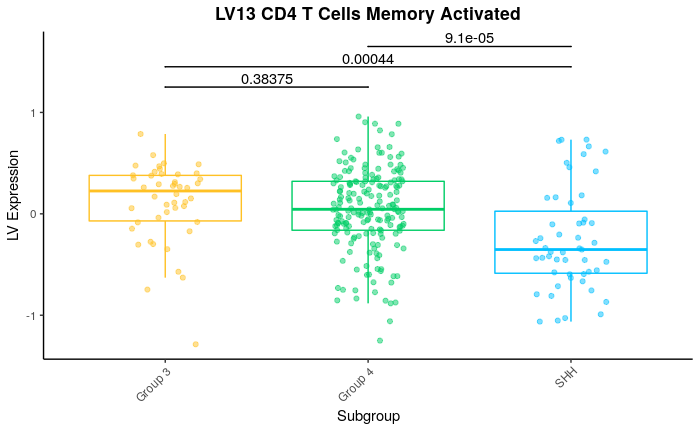

```r
lv13_df %>%
  ggplot(aes(x = subgroup, y = Expression_level,
             group = subgroup, colour = subgroup)) +
  geom_boxplot(outlier.shape = NA) +  # we remove outlier points because they
  # will be included in the jitter
  geom_jitter(width = 0.175, alpha = 0.5) +
  # add built in theme
  theme_classic() +
  labs(x = "Subgroup", y = "LV Expression", title = "LV13 CD4 T Cells Memory Activated") +
  theme(plot.title = element_text(hjust = 0.5, face = "bold"),
        axis.text.x = element_text(hjust = 1, angle = 45),
        legend.position = "none") +
  scale_colour_manual(values = c("#FFC125", "#00CD66", "#00BFFF")) +
  geom_signif(y_position = c(1.25, 1.45, 1.65),
              xmin = c("Group 3", "Group 3", "Group 4"),
              xmax = c("Group 4", "SHH", "SHH"),
              annotation = c("0.38375", "0.00044", "9.1e-05"),
              tip_length = 0, color = "black")
```

### Save to file

`ggplot2` has a function `ggsave` that we will use to save a pdf of the last plot we ran.

```r
ggsave(lv_plot, plot = last_plot())
```